# Predicting Activity Quality From Activity Monitors

PC

Saturday, June 20, 2015

## Background

In this project, the goal was to use data from accelerometers on the belt, forearm, arm, and dumbell of 6 participants to predict whether the dumbell exercise was performed correctly or not. The participants were asked to perform dumbell lifts correctly and incorrectly in 5 different ways. More information is available from the website here: http://groupware.les.inf.puc-rio.br/har (see the section on the Weight Lifting Exercise Dataset).

## Data

The data was downloaded and cleaned by removing columns with NAs and “#Div/0!”. In addition the rows, with summary information of the completed exercise were removed, as this information is only available after the completion of the exercise.

```r
rawtrain <- read.csv("D:\\Library\\Coursera\\Data Science Specialization\\Practical Machine Learning\\pml-training.csv")
rawtest <- read.csv("D:\\Library\\Coursera\\Data Science Specialization\\Practical Machine Learning\\pml-testing.csv")

# clean data
data <- rawtrain[which(rawtrain$new_window == "no"), c(8:11, 37:49, 60:68, 84:86, 102, 113:124, 140, 151:159, 160)] # NAs etc
summary(data) # 19216 x 53
```

```
##    roll_belt        pitch_belt          yaw_belt       total_accel_belt
##  Min.   :-28.90   Min.   :-55.8000   Min.   :-180.00   Min.   : 0.0
##  1st Qu.:  1.10   1st Qu.:  1.7700   1st Qu.: -88.30   1st Qu.: 3.0
##  Median :113.00   Median :  5.2800   Median : -13.20   Median :17.0
##  Mean   : 64.33   Mean   :  0.3017   Mean   : -11.26   Mean   :11.3
##  3rd Qu.:123.00   3rd Qu.: 14.9000   3rd Qu.:  12.82   3rd Qu.:18.0
##  Max.   :162.00   Max.   : 60.3000   Max.   : 179.00   Max.   :29.0
##   gyros_belt_x        gyros_belt_y       gyros_belt_z
##  Min.   :-1.040000   Min.   :-0.64000   Min.   :-1.4600
##  1st Qu.:-0.030000   1st Qu.: 0.00000   1st Qu.:-0.2000
##  Median : 0.030000   Median : 0.02000   Median :-0.1000
##  Mean   :-0.005605   Mean   : 0.03948   Mean   :-0.1306
##  3rd Qu.: 0.110000   3rd Qu.: 0.11000   3rd Qu.:-0.0200
##  Max.   : 2.220000   Max.   : 0.64000   Max.   : 1.6200
##   accel_belt_x       accel_belt_y     accel_belt_z     magnet_belt_x
##  Min.   :-120.000   Min.   :-69.00   Min.   :-275.00   Min.   :-52.00
##  1st Qu.: -21.000   1st Qu.:  3.00   1st Qu.:-162.00   1st Qu.:  9.00
##  Median : -15.000   Median : 34.00   Median :-152.00   Median : 35.00
##  Mean   :  -5.597   Mean   : 30.11   Mean   : -72.48   Mean   : 55.57
##  3rd Qu.:  -5.000   3rd Qu.: 61.00   3rd Qu.:  27.00   3rd Qu.: 59.00
##  Max.   :  85.000   Max.   :164.00   Max.   : 105.00   Max.   :485.00
##  magnet_belt_y   magnet_belt_z       roll_arm         pitch_arm
##  Min.   :354.0   Min.   :-623.0   Min.   :-180.00   Min.   :-88.800
##  1st Qu.:581.0   1st Qu.:-375.0   1st Qu.: -31.60   1st Qu.:-25.900
##  Median :601.0   Median :-319.5   Median :   0.00   Median :  0.000
##  Mean   :593.7   Mean   :-345.5   Mean   :  17.89   Mean   : -4.635
##  3rd Qu.:610.0   3rd Qu.:-306.0   3rd Qu.:  77.30   3rd Qu.: 11.200
##  Max.   :673.0   Max.   : 293.0   Max.   : 180.00   Max.   : 88.500
##     yaw_arm          total_accel_arm  gyros_arm_x        gyros_arm_y
##  Min.   :-180.0000   Min.   : 1.00   Min.   :-6.37000   Min.   :-3.4000
##  1st Qu.: -43.1000   1st Qu.:17.00   1st Qu.:-1.33000   1st Qu.:-0.8000
##  Median :   0.0000   Median :27.00   Median : 0.08000   Median :-0.2400
##  Mean   :  -0.6277   Mean   :25.52   Mean   : 0.04298   Mean   :-0.2573
##  3rd Qu.:  45.8000   3rd Qu.:33.00   3rd Qu.: 1.56000   3rd Qu.: 0.1400
##  Max.   : 180.0000   Max.   :66.00   Max.   : 4.87000   Max.   : 2.8400
##   gyros_arm_z       accel_arm_x       accel_arm_y       accel_arm_z
##  Min.   :-2.3300   Min.   :-404.00   Min.   :-318.00   Min.   :-636.00
##  1st Qu.:-0.0700   1st Qu.:-242.00   1st Qu.: -54.00   1st Qu.:-144.00
##  Median : 0.2300   Median : -44.00   Median :  14.00   Median : -47.00
##  Mean   : 0.2694   Mean   : -60.26   Mean   :  32.65   Mean   : -71.41
```

[output cut: 50 more lines]

```
##  Max.   :311.00000   Max.   :231.000   Max.   : 477.00   Max.   : 923.0
##  accel_forearm_z   magnet_forearm_x  magnet_forearm_y magnet_forearm_z
##  Min.   :-446.00   Min.   :-1280.0   Min.   :-896.0   Min.   :-973.0
##  1st Qu.:-182.00   1st Qu.: -616.0   1st Qu.:   4.0   1st Qu.: 189.0
##  Median : -39.00   Median : -377.0   Median : 592.0   Median : 511.0
##  Mean   : -55.22   Mean   : -312.3   Mean   : 380.6   Mean   : 393.4
##  3rd Qu.:  26.00   3rd Qu.:  -73.0   3rd Qu.: 737.0   3rd Qu.: 653.0
##  Max.   : 291.00   Max.   :  672.0   Max.   :1480.0   Max.   :1090.0
##  classe
##  A:5471
##  B:3718
##  C:3352
##  D:3147
##  E:3528
##
```

## Model

The supplied training data was split 60:40 training:test, and prior to running the algo, the data was preprocessed by centring and scaling.

```r
# preProcess data
library(caret)
inTrain = createDataPartition(data$classe, p = 0.6)[[1]]
train = data[inTrain, ]
test = data[-inTrain, ]
set.seed(989)
fit <- train(classe ~ ., data = train, method = "rf", preProc = c("center", "scale"),
             trControl = trainControl(method = "cv", number = 5), prox = TRUE)
print(fit)
```

```
## Random Forest
##
## 11532 samples
##    52 predictor
##     5 classes: 'A', 'B', 'C', 'D', 'E'
##
## Pre-processing: centered, scaled
## Resampling: Cross-Validated (5 fold)
##
## Summary of sample sizes: 9225, 9225, 9225, 9225, 9228
##
## Resampling results across tuning parameters:
##
##   mtry  Accuracy   Kappa      Accuracy SD  Kappa SD
##    2    0.9882063  0.9850774  0.001775456  0.002245818
##   27    0.9885532  0.9855172  0.002919710  0.003695907
##   52    0.9797962  0.9744348  0.005921299  0.007491754
##
## Accuracy was used to select the optimal model using  the largest value.
## The final value used for the model was mtry = 27.
```

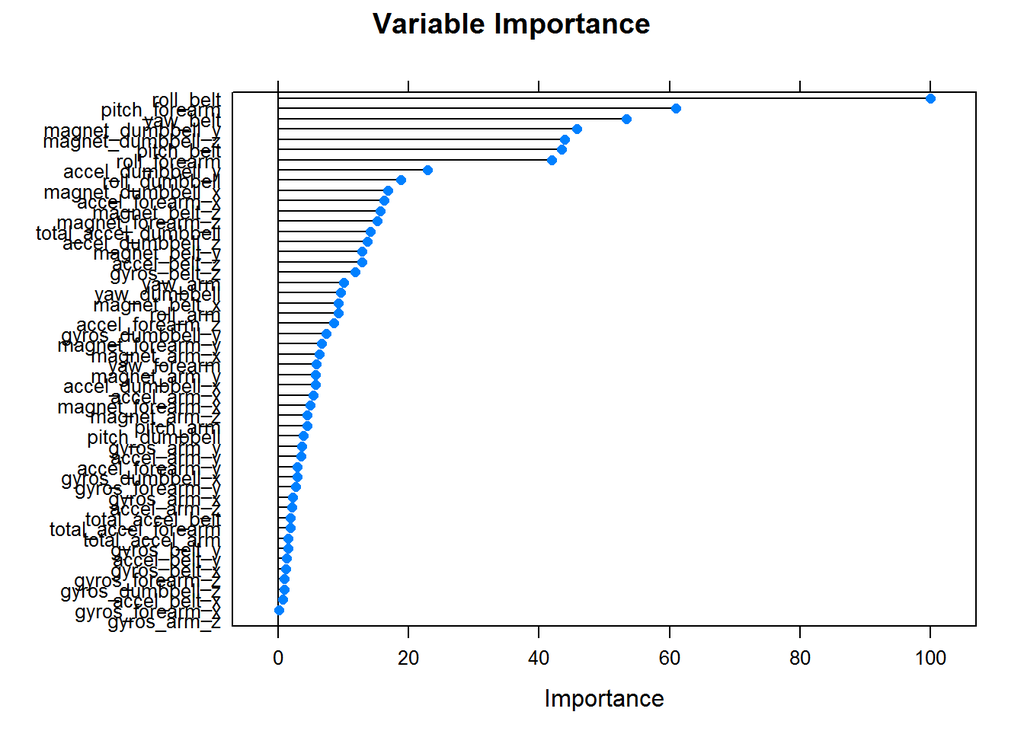

```r
plot(varImp(fit), main = "Variable Importance")
```

```r
print(fit$finalModel)
```

```
##
## Call:
##  randomForest(x = x, y = y, mtry = param$mtry, proximity = TRUE)
##                Type of random forest: classification
##                      Number of trees: 500
## No. of variables tried at each split: 27
##
##         OOB estimate of  error rate: 0.96%
## Confusion matrix:
##      A    B    C    D    E  class.error
## A 3280    2    0    0    1 0.0009137984
## B   21 2199   11    0    0 0.0143433438
## C    0   23 1983    6    0 0.0144135189
## D    0    1   29 1856    3 0.0174695606
## E    0    2    3    9 2103 0.0066131318
```

## Cross-Validation

According to http://www.stat.berkeley.edu/~breiman/RandomForests/cc_home.htm#ooberr it is not necessary to use cross-validation:

> The out-of-bag (oob) error estimate In random forests, there is no need for cross-validation or a separate test set to get an unbiased estimate of the test set error. It is estimated internally

## Actual Out-of-sample Error

In addition, for comparsion purposes, here are the results of the out-of-sample test using the 40% of data from the unseen test set, with an actual out-of-sample error rate of 0.87%.

```r
fit_test <- predict(fit, newdata = test[, -NCOL(data)])
confusionMatrix(predict(fit, newdata = test[, -NCOL(data)]), test$classe)
```

```
## Confusion Matrix and Statistics
##
##           Reference
## Prediction    A    B    C    D    E
##          A 2187   17    0    0    0
##          B    0 1467   11    1    4
##          C    0    3 1321   18    1
##          D    0    0    8 1238    2
##          E    1    0    0    1 1404
##
## Overall Statistics
##
##                Accuracy : 0.9913
##                  95% CI : (0.9889, 0.9932)
##     No Information Rate : 0.2847
##     P-Value [Acc > NIR] : < 2.2e-16
##
##                   Kappa : 0.989
##  Mcnemar's Test P-Value : NA
##
## Statistics by Class:
##
##                      Class: A Class: B Class: C Class: D Class: E
## Sensitivity            0.9995   0.9866   0.9858   0.9841   0.9950
## Specificity            0.9969   0.9974   0.9965   0.9984   0.9997
## Pos Pred Value         0.9923   0.9892   0.9836   0.9920   0.9986
## Neg Pred Value         0.9998   0.9968   0.9970   0.9969   0.9989
## Prevalence             0.2847   0.1935   0.1744   0.1637   0.1836
## Detection Rate         0.2846   0.1909   0.1719   0.1611   0.1827
## Detection Prevalence   0.2868   0.1930   0.1748   0.1624   0.1830
## Balanced Accuracy      0.9982   0.9920   0.9912   0.9913   0.9974
```